# Risk Factor Analysis

## Outcome Variable

**Outcome Variable:** whz

## Predictor Variables

**Intervention Variable:** predfeed36

**Adjustment Set:**

- arm
- sex
- month
- brthmon
- W_mage
- meducyrs
- feducyrs
- hhwealth_quart
- hfoodsec
- W_mhtcm
- vagbrth
- W_gagebrth
- W_birthwt
- W_birthlen
- W_nrooms
- W_nchldlt5
- W_parity
- impfloor
- impsan
- safeh20
- delta_W_mage
- delta_meducyrs
- delta_feducyrs
- delta_hhwealth_quart
- delta_hfoodsec
- delta_W_mhtcm
- delta_vagbrth
- delta_W_gagebrth
- delta_W_birthwt
- delta_W_birthlen
- delta_W_nrooms
- delta_W_nchldlt5
- delta_W_parity
- delta_impfloor
- delta_impsan
- delta_safeh20

## Stratifying Variables

The analysis was stratified on these variable(s):

- agecat
- studyid
- country

## Data Summary

| agecat | studyid | country | predfeed36 | n_cell | n |
| --- | --- | --- | --- | --- | --- |
| Birth | ki0047075b-MAL-ED | BANGLADESH | 1 | 120 | 230 |
| Birth | ki0047075b-MAL-ED | BANGLADESH | 0 | 110 | 230 |
| Birth | ki0047075b-MAL-ED | BRAZIL | 1 | 28 | 177 |
| Birth | ki0047075b-MAL-ED | BRAZIL | 0 | 149 | 177 |
| Birth | ki0047075b-MAL-ED | INDIA | 1 | 16 | 195 |
| Birth | ki0047075b-MAL-ED | INDIA | 0 | 179 | 195 |
| Birth | ki0047075b-MAL-ED | NEPAL | 1 | 25 | 167 |
| Birth | ki0047075b-MAL-ED | NEPAL | 0 | 142 | 167 |
| Birth | ki0047075b-MAL-ED | PERU | 1 | 116 | 266 |
| Birth | ki0047075b-MAL-ED | PERU | 0 | 150 | 266 |
| Birth | ki0047075b-MAL-ED | SOUTH AFRICA | 1 | 3 | 234 |
| Birth | ki0047075b-MAL-ED | SOUTH AFRICA | 0 | 231 | 234 |
| Birth | ki0047075b-MAL-ED | TANZANIA, UNITED REPUBLIC OF | 1 | 1 | 116 |
| Birth | ki0047075b-MAL-ED | TANZANIA, UNITED REPUBLIC OF | 0 | 115 | 116 |
| Birth | ki1000109-EE | PAKISTAN | 1 | 0 | 1 |
| Birth | ki1000109-EE | PAKISTAN | 0 | 1 | 1 |
| Birth | kiGH5241-JiVitA-3 | BANGLADESH | 1 | 9192 | 11319 |
| Birth | kiGH5241-JiVitA-3 | BANGLADESH | 0 | 2127 | 11319 |
| Birth | kiGH5241-JiVitA-4 | BANGLADESH | 1 | 493 | 602 |
| Birth | kiGH5241-JiVitA-4 | BANGLADESH | 0 | 109 | 602 |
| 6 months | ki0047075b-MAL-ED | BANGLADESH | 1 | 129 | 240 |
| 6 months | ki0047075b-MAL-ED | BANGLADESH | 0 | 111 | 240 |
| 6 months | ki0047075b-MAL-ED | BRAZIL | 1 | 37 | 209 |
| 6 months | ki0047075b-MAL-ED | BRAZIL | 0 | 172 | 209 |
| 6 months | ki0047075b-MAL-ED | INDIA | 1 | 19 | 236 |
| 6 months | ki0047075b-MAL-ED | INDIA | 0 | 217 | 236 |
| 6 months | ki0047075b-MAL-ED | NEPAL | 1 | 32 | 236 |
| 6 months | ki0047075b-MAL-ED | NEPAL | 0 | 204 | 236 |
| 6 months | ki0047075b-MAL-ED | PERU | 1 | 126 | 271 |
| 6 months | ki0047075b-MAL-ED | PERU | 0 | 145 | 271 |
| 6 months | ki0047075b-MAL-ED | SOUTH AFRICA | 1 | 3 | 254 |
| 6 months | ki0047075b-MAL-ED | SOUTH AFRICA | 0 | 251 | 254 |
| 6 months | ki0047075b-MAL-ED | TANZANIA, UNITED REPUBLIC OF | 1 | 2 | 247 |
| 6 months | ki0047075b-MAL-ED | TANZANIA, UNITED REPUBLIC OF | 0 | 245 | 247 |
| 6 months | ki1000109-EE | PAKISTAN | 1 | 224 | 371 |
| 6 months | ki1000109-EE | PAKISTAN | 0 | 147 | 371 |
| 6 months | ki1000304b-SAS-FoodSuppl | INDIA | 1 | 0 | 168 |
| 6 months | ki1000304b-SAS-FoodSuppl | INDIA | 0 | 168 | 168 |
| 6 months | ki1113344-GMS-Nepal | NEPAL | 1 | 423 | 526 |
| 6 months | ki1113344-GMS-Nepal | NEPAL | 0 | 103 | 526 |
| 6 months | ki1148112-LCNI-5 | MALAWI | 1 | 47 | 272 |
| 6 months | ki1148112-LCNI-5 | MALAWI | 0 | 225 | 272 |
| 6 months | kiGH5241-JiVitA-3 | BANGLADESH | 1 | 10674 | 13353 |
| 6 months | kiGH5241-JiVitA-3 | BANGLADESH | 0 | 2679 | 13353 |
| 6 months | kiGH5241-JiVitA-4 | BANGLADESH | 1 | 3255 | 4172 |
| 6 months | kiGH5241-JiVitA-4 | BANGLADESH | 0 | 917 | 4172 |
| 24 months | ki0047075b-MAL-ED | BANGLADESH | 1 | 117 | 211 |
| 24 months | ki0047075b-MAL-ED | BANGLADESH | 0 | 94 | 211 |
| 24 months | ki0047075b-MAL-ED | BRAZIL | 1 | 30 | 169 |
| 24 months | ki0047075b-MAL-ED | BRAZIL | 0 | 139 | 169 |
| 24 months | ki0047075b-MAL-ED | INDIA | 1 | 18 | 227 |
| 24 months | ki0047075b-MAL-ED | INDIA | 0 | 209 | 227 |
| 24 months | ki0047075b-MAL-ED | NEPAL | 1 | 30 | 228 |
| 24 months | ki0047075b-MAL-ED | NEPAL | 0 | 198 | 228 |
| 24 months | ki0047075b-MAL-ED | PERU | 1 | 94 | 200 |
| 24 months | ki0047075b-MAL-ED | PERU | 0 | 106 | 200 |
| 24 months | ki0047075b-MAL-ED | SOUTH AFRICA | 1 | 3 | 238 |
| 24 months | ki0047075b-MAL-ED | SOUTH AFRICA | 0 | 235 | 238 |
| 24 months | ki0047075b-MAL-ED | TANZANIA, UNITED REPUBLIC OF | 1 | 2 | 214 |
| 24 months | ki0047075b-MAL-ED | TANZANIA, UNITED REPUBLIC OF | 0 | 212 | 214 |
| 24 months | ki1113344-GMS-Nepal | NEPAL | 1 | 368 | 455 |
| 24 months | ki1113344-GMS-Nepal | NEPAL | 0 | 87 | 455 |
| 24 months | ki1148112-LCNI-5 | MALAWI | 1 | 34 | 184 |
| 24 months | ki1148112-LCNI-5 | MALAWI | 0 | 150 | 184 |
| 24 months | kiGH5241-JiVitA-3 | BANGLADESH | 1 | 5276 | 6672 |
| 24 months | kiGH5241-JiVitA-3 | BANGLADESH | 0 | 1396 | 6672 |
| 24 months | kiGH5241-JiVitA-4 | BANGLADESH | 1 | 3140 | 4009 |
| 24 months | kiGH5241-JiVitA-4 | BANGLADESH | 0 | 869 | 4009 |

The following strata were considered:

- agecat: 24 months, studyid: ki0047075b-MAL-ED, country: BANGLADESH
- agecat: 24 months, studyid: ki0047075b-MAL-ED, country: BRAZIL
- agecat: 24 months, studyid: ki0047075b-MAL-ED, country: INDIA
- agecat: 24 months, studyid: ki0047075b-MAL-ED, country: NEPAL
- agecat: 24 months, studyid: ki0047075b-MAL-ED, country: PERU
- agecat: 24 months, studyid: ki0047075b-MAL-ED, country: SOUTH AFRICA
- agecat: 24 months, studyid: ki0047075b-MAL-ED, country: TANZANIA, UNITED REPUBLIC OF
- agecat: 24 months, studyid: ki1113344-GMS-Nepal, country: NEPAL
- agecat: 24 months, studyid: ki1148112-LCNI-5, country: MALAWI
- agecat: 24 months, studyid: kiGH5241-JiVitA-3, country: BANGLADESH
- agecat: 24 months, studyid: kiGH5241-JiVitA-4, country: BANGLADESH
- agecat: 6 months, studyid: ki0047075b-MAL-ED, country: BANGLADESH
- agecat: 6 months, studyid: ki0047075b-MAL-ED, country: BRAZIL
- agecat: 6 months, studyid: ki0047075b-MAL-ED, country: INDIA
- agecat: 6 months, studyid: ki0047075b-MAL-ED, country: NEPAL
- agecat: 6 months, studyid: ki0047075b-MAL-ED, country: PERU
- agecat: 6 months, studyid: ki0047075b-MAL-ED, country: SOUTH AFRICA
- agecat: 6 months, studyid: ki0047075b-MAL-ED, country: TANZANIA, UNITED REPUBLIC OF
- agecat: 6 months, studyid: ki1000109-EE, country: PAKISTAN
- agecat: 6 months, studyid: ki1000304b-SAS-FoodSuppl, country: INDIA
- agecat: 6 months, studyid: ki1113344-GMS-Nepal, country: NEPAL
- agecat: 6 months, studyid: ki1148112-LCNI-5, country: MALAWI
- agecat: 6 months, studyid: kiGH5241-JiVitA-3, country: BANGLADESH
- agecat: 6 months, studyid: kiGH5241-JiVitA-4, country: BANGLADESH
- agecat: Birth, studyid: ki0047075b-MAL-ED, country: BANGLADESH
- agecat: Birth, studyid: ki0047075b-MAL-ED, country: BRAZIL
- agecat: Birth, studyid: ki0047075b-MAL-ED, country: INDIA
- agecat: Birth, studyid: ki0047075b-MAL-ED, country: NEPAL
- agecat: Birth, studyid: ki0047075b-MAL-ED, country: PERU
- agecat: Birth, studyid: ki0047075b-MAL-ED, country: SOUTH AFRICA
- agecat: Birth, studyid: ki0047075b-MAL-ED, country: TANZANIA, UNITED REPUBLIC OF
- agecat: Birth, studyid: ki1000109-EE, country: PAKISTAN
- agecat: Birth, studyid: kiGH5241-JiVitA-3, country: BANGLADESH
- agecat: Birth, studyid: kiGH5241-JiVitA-4, country: BANGLADESH

### Dropped Strata

Some strata were dropped due to rare outcomes:

- agecat: Birth, studyid: ki0047075b-MAL-ED, country: SOUTH AFRICA
- agecat: Birth, studyid: ki0047075b-MAL-ED, country: TANZANIA, UNITED REPUBLIC OF
- agecat: Birth, studyid: ki1000109-EE, country: PAKISTAN
- agecat: 6 months, studyid: ki0047075b-MAL-ED, country: SOUTH AFRICA
- agecat: 6 months, studyid: ki0047075b-MAL-ED, country: TANZANIA, UNITED REPUBLIC OF
- agecat: 6 months, studyid: ki1000304b-SAS-FoodSuppl, country: INDIA
- agecat: 24 months, studyid: ki0047075b-MAL-ED, country: SOUTH AFRICA
- agecat: 24 months, studyid: ki0047075b-MAL-ED, country: TANZANIA, UNITED REPUBLIC OF

## Methods Detail

We’re interested in the causal parameters $E[Y_a]$ for all values of $a \in \mathcal{A}$. These parameters represent the mean outcome if, possibly contrary to fact, we intervened to set all units to have $A=a$. Under the randomization and positivity assumptions, these are identified by the statistical parameters $\psi_a=E_W[E_{Y|A,W}(Y|A=a,W)]$. In addition, we’re interested in the mean of $Y$, $E[Y]$ under no intervention (the observed mean). We will estimate these parameters by using SuperLearner to fit the relevant likelihood factors – $E_{Y|A,W}(Y|A=a,W)$ and $p(A=a|W)$, and then updating our likelihood fit using a joint TMLE.

For unadjusted analyses ($W=\{\}$), initial likelihoods were estimated using Lrnr_glm to estimate the simple $E(Y|A)$ and Lrnr_mean to estimate $p(A)$. For adjusted analyses, a small library containing Lrnr_glmnet, Lrnr_xgboost, and Lrnr_mean was used.

Having estimated these parameters, we will then use the delta method to estimate relative risks and attributable risks relative to a prespecified baseline level of $A$.

# Results Detail

## Results Plots

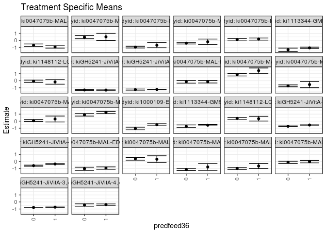

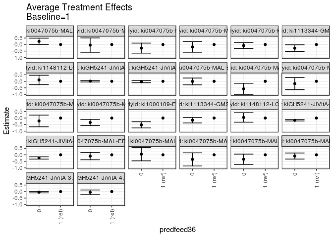

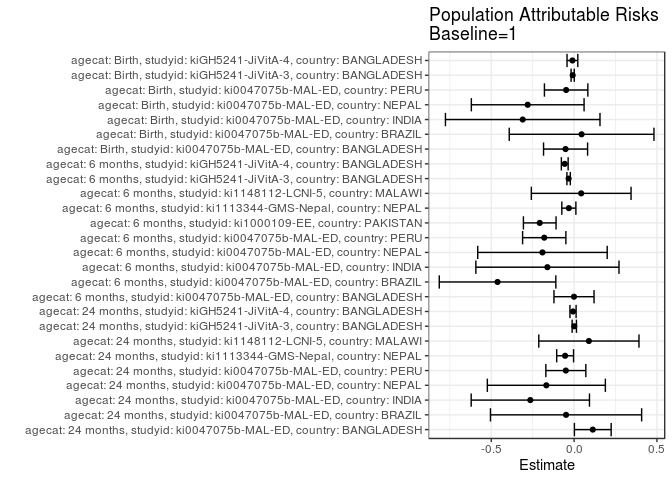

## Results Table

### Parameter: TSM

| agecat | studyid | country | intervention_level | baseline_level | estimate | ci_lower | ci_upper |
| --- | --- | --- | --- | --- | --- | --- | --- |
| Birth | ki0047075b-MAL-ED | BANGLADESH | 1 | NA | -0.9257683 | -1.0962852 | -0.7552515 |
| Birth | ki0047075b-MAL-ED | BANGLADESH | 0 | NA | -1.0264492 | -1.2485595 | -0.8043389 |
| Birth | ki0047075b-MAL-ED | BRAZIL | 1 | NA | 0.3385143 | -0.1424912 | 0.8195198 |
| Birth | ki0047075b-MAL-ED | BRAZIL | 0 | NA | 0.3880581 | 0.1964332 | 0.5796829 |
| Birth | ki0047075b-MAL-ED | INDIA | 1 | NA | -0.7715203 | -1.2506753 | -0.2923653 |
| Birth | ki0047075b-MAL-ED | INDIA | 0 | NA | -1.1229782 | -1.2716801 | -0.9742763 |
| Birth | ki0047075b-MAL-ED | NEPAL | 1 | NA | -0.6326985 | -0.9969406 | -0.2684565 |
| Birth | ki0047075b-MAL-ED | NEPAL | 0 | NA | -0.9728448 | -1.1230459 | -0.8226438 |
| Birth | ki0047075b-MAL-ED | PERU | 1 | NA | -0.0121304 | -0.1825618 | 0.1583009 |
| Birth | ki0047075b-MAL-ED | PERU | 0 | NA | -0.1062456 | -0.2611948 | 0.0487036 |
| Birth | kiGH5241-JiVitA-3 | BANGLADESH | 1 | NA | -0.7359503 | -0.7606078 | -0.7112929 |
| Birth | kiGH5241-JiVitA-3 | BANGLADESH | 0 | NA | -0.7848491 | -0.8326210 | -0.7370772 |
| Birth | kiGH5241-JiVitA-4 | BANGLADESH | 1 | NA | -0.3759824 | -0.4692454 | -0.2827194 |
| Birth | kiGH5241-JiVitA-4 | BANGLADESH | 0 | NA | -0.4344620 | -0.5981935 | -0.2707305 |
| 6 months | ki0047075b-MAL-ED | BANGLADESH | 1 | NA | -0.1393862 | -0.3173388 | 0.0385664 |
| 6 months | ki0047075b-MAL-ED | BANGLADESH | 0 | NA | -0.1489866 | -0.3402597 | 0.0422866 |
| 6 months | ki0047075b-MAL-ED | BRAZIL | 1 | NA | 1.4337171 | 1.0491121 | 1.8183220 |
| 6 months | ki0047075b-MAL-ED | BRAZIL | 0 | NA | 0.8600700 | 0.6812211 | 1.0389189 |
| 6 months | ki0047075b-MAL-ED | INDIA | 1 | NA | -0.5423759 | -0.9865235 | -0.0982283 |
| 6 months | ki0047075b-MAL-ED | INDIA | 0 | NA | -0.7218644 | -0.8536001 | -0.5901286 |
| 6 months | ki0047075b-MAL-ED | NEPAL | 1 | NA | 0.3020185 | -0.1221151 | 0.7261520 |
| 6 months | ki0047075b-MAL-ED | NEPAL | 0 | NA | 0.0802038 | -0.0581485 | 0.2185561 |
| 6 months | ki0047075b-MAL-ED | PERU | 1 | NA | 1.2364810 | 1.0726481 | 1.4003138 |
| 6 months | ki0047075b-MAL-ED | PERU | 0 | NA | 0.8976411 | 0.7208771 | 1.0744052 |
| 6 months | ki1000109-EE | PAKISTAN | 1 | NA | -0.5181898 | -0.6607153 | -0.3756644 |
| 6 months | ki1000109-EE | PAKISTAN | 0 | NA | -1.0385847 | -1.2254973 | -0.8516721 |
| 6 months | ki1113344-GMS-Nepal | NEPAL | 1 | NA | -0.5690121 | -0.6693198 | -0.4687044 |
| 6 months | ki1113344-GMS-Nepal | NEPAL | 0 | NA | -0.7297307 | -0.9200478 | -0.5394136 |
| 6 months | ki1148112-LCNI-5 | MALAWI | 1 | NA | 0.3500275 | 0.0115896 | 0.6884653 |
| 6 months | ki1148112-LCNI-5 | MALAWI | 0 | NA | 0.3954875 | 0.2685305 | 0.5224445 |
| 6 months | kiGH5241-JiVitA-3 | BANGLADESH | 1 | NA | -0.5502914 | -0.5739789 | -0.5266039 |
| 6 months | kiGH5241-JiVitA-3 | BANGLADESH | 0 | NA | -0.7243561 | -0.7719017 | -0.6768105 |
| 6 months | kiGH5241-JiVitA-4 | BANGLADESH | 1 | NA | -0.3408610 | -0.3881538 | -0.2935681 |
| 6 months | kiGH5241-JiVitA-4 | BANGLADESH | 0 | NA | -0.5813024 | -0.6573297 | -0.5052751 |
| 24 months | ki0047075b-MAL-ED | BANGLADESH | 1 | NA | -0.9354649 | -1.1026572 | -0.7682726 |
| 24 months | ki0047075b-MAL-ED | BANGLADESH | 0 | NA | -0.6917635 | -0.8755896 | -0.5079374 |
| 24 months | ki0047075b-MAL-ED | BRAZIL | 1 | NA | 0.4951955 | -0.0078228 | 0.9982138 |
| 24 months | ki0047075b-MAL-ED | BRAZIL | 0 | NA | 0.4528696 | 0.2269543 | 0.6787848 |
| 24 months | ki0047075b-MAL-ED | INDIA | 1 | NA | -0.6881171 | -1.0510965 | -0.3251376 |
| 24 months | ki0047075b-MAL-ED | INDIA | 0 | NA | -0.9625832 | -1.0846982 | -0.8404683 |
| 24 months | ki0047075b-MAL-ED | NEPAL | 1 | NA | -0.2089668 | -0.5978055 | 0.1798720 |
| 24 months | ki0047075b-MAL-ED | NEPAL | 0 | NA | -0.3924384 | -0.5102970 | -0.2745798 |
| 24 months | ki0047075b-MAL-ED | PERU | 1 | NA | 0.1800761 | 0.0327527 | 0.3273994 |
| 24 months | ki0047075b-MAL-ED | PERU | 0 | NA | 0.0993089 | -0.0786346 | 0.2772524 |
| 24 months | ki1113344-GMS-Nepal | NEPAL | 1 | NA | -1.0644623 | -1.1622497 | -0.9666748 |
| 24 months | ki1113344-GMS-Nepal | NEPAL | 0 | NA | -1.3419799 | -1.5826869 | -1.1012728 |
| 24 months | ki1148112-LCNI-5 | MALAWI | 1 | NA | -0.1662736 | -0.4896107 | 0.1570636 |
| 24 months | ki1148112-LCNI-5 | MALAWI | 0 | NA | -0.0625339 | -0.2234299 | 0.0983621 |
| 24 months | kiGH5241-JiVitA-3 | BANGLADESH | 1 | NA | -1.3257306 | -1.3565024 | -1.2949588 |
| 24 months | kiGH5241-JiVitA-3 | BANGLADESH | 0 | NA | -1.3141542 | -1.3696291 | -1.2586794 |
| 24 months | kiGH5241-JiVitA-4 | BANGLADESH | 1 | NA | -1.2353078 | -1.2735109 | -1.1971046 |
| 24 months | kiGH5241-JiVitA-4 | BANGLADESH | 0 | NA | -1.2582962 | -1.3396900 | -1.1769023 |

### Parameter: E(Y)

| agecat | studyid | country | intervention_level | baseline_level | estimate | ci_lower | ci_upper |
| --- | --- | --- | --- | --- | --- | --- | --- |
| Birth | ki0047075b-MAL-ED | BANGLADESH | NA | NA | -0.9773043 | -1.1153078 | -0.8393008 |
| Birth | ki0047075b-MAL-ED | BRAZIL | NA | NA | 0.3837288 | 0.2059602 | 0.5614974 |
| Birth | ki0047075b-MAL-ED | INDIA | NA | NA | -1.0816410 | -1.2241126 | -0.9391694 |
| Birth | ki0047075b-MAL-ED | NEPAL | NA | NA | -0.9126946 | -1.0520834 | -0.7733058 |
| Birth | ki0047075b-MAL-ED | PERU | NA | NA | -0.0602256 | -0.1729666 | 0.0525155 |
| Birth | kiGH5241-JiVitA-3 | BANGLADESH | NA | NA | -0.7445605 | -0.7677110 | -0.7214100 |
| Birth | kiGH5241-JiVitA-4 | BANGLADESH | NA | NA | -0.3861794 | -0.4712311 | -0.3011277 |
| 6 months | ki0047075b-MAL-ED | BANGLADESH | NA | NA | -0.1400243 | -0.2696346 | -0.0104140 |
| 6 months | ki0047075b-MAL-ED | BRAZIL | NA | NA | 0.9717225 | 0.8073791 | 1.1360658 |
| 6 months | ki0047075b-MAL-ED | INDIA | NA | NA | -0.7033969 | -0.8285284 | -0.5782654 |
| 6 months | ki0047075b-MAL-ED | NEPAL | NA | NA | 0.1110452 | -0.0202712 | 0.2423616 |
| 6 months | ki0047075b-MAL-ED | PERU | NA | NA | 1.0562362 | 0.9338834 | 1.1785889 |
| 6 months | ki1000109-EE | PAKISTAN | NA | NA | -0.7256065 | -0.8395859 | -0.6116270 |
| 6 months | ki1113344-GMS-Nepal | NEPAL | NA | NA | -0.6007161 | -0.6897580 | -0.5116742 |
| 6 months | ki1148112-LCNI-5 | MALAWI | NA | NA | 0.3927574 | 0.2737700 | 0.5117448 |
| 6 months | kiGH5241-JiVitA-3 | BANGLADESH | NA | NA | -0.5834618 | -0.6054534 | -0.5614701 |
| 6 months | kiGH5241-JiVitA-4 | BANGLADESH | NA | NA | -0.3973178 | -0.4385298 | -0.3561058 |
| 24 months | ki0047075b-MAL-ED | BANGLADESH | NA | NA | -0.8227962 | -0.9454140 | -0.7001785 |
| 24 months | ki0047075b-MAL-ED | BRAZIL | NA | NA | 0.4466272 | 0.2416144 | 0.6516401 |
| 24 months | ki0047075b-MAL-ED | INDIA | NA | NA | -0.9522907 | -1.0676596 | -0.8369219 |
| 24 months | ki0047075b-MAL-ED | NEPAL | NA | NA | -0.3764474 | -0.4898516 | -0.2630431 |
| 24 months | ki0047075b-MAL-ED | PERU | NA | NA | 0.1302000 | 0.0113848 | 0.2490152 |
| 24 months | ki1113344-GMS-Nepal | NEPAL | NA | NA | -1.1186923 | -1.2105469 | -1.0268377 |
| 24 months | ki1148112-LCNI-5 | MALAWI | NA | NA | -0.0771196 | -0.2204715 | 0.0662323 |
| 24 months | kiGH5241-JiVitA-3 | BANGLADESH | NA | NA | -1.3246418 | -1.3519597 | -1.2973238 |
| 24 months | kiGH5241-JiVitA-4 | BANGLADESH | NA | NA | -1.2418558 | -1.2769820 | -1.2067296 |

### Parameter: ATE

| agecat | studyid | country | intervention_level | baseline_level | estimate | ci_lower | ci_upper |
| --- | --- | --- | --- | --- | --- | --- | --- |
| Birth | ki0047075b-MAL-ED | BANGLADESH | 1 | 1 | 0.0000000 | 0.0000000 | 0.0000000 |
| Birth | ki0047075b-MAL-ED | BANGLADESH | 0 | 1 | -0.1006809 | -0.3807997 | 0.1794379 |
| Birth | ki0047075b-MAL-ED | BRAZIL | 1 | 1 | 0.0000000 | 0.0000000 | 0.0000000 |
| Birth | ki0047075b-MAL-ED | BRAZIL | 0 | 1 | 0.0495438 | -0.4620337 | 0.5611212 |
| Birth | ki0047075b-MAL-ED | INDIA | 1 | 1 | 0.0000000 | 0.0000000 | 0.0000000 |
| Birth | ki0047075b-MAL-ED | INDIA | 0 | 1 | -0.3514579 | -0.8544921 | 0.1515762 |
| Birth | ki0047075b-MAL-ED | NEPAL | 1 | 1 | 0.0000000 | 0.0000000 | 0.0000000 |
| Birth | ki0047075b-MAL-ED | NEPAL | 0 | 1 | -0.3401463 | -0.7345254 | 0.0542328 |
| Birth | ki0047075b-MAL-ED | PERU | 1 | 1 | 0.0000000 | 0.0000000 | 0.0000000 |
| Birth | ki0047075b-MAL-ED | PERU | 0 | 1 | -0.0941151 | -0.3252555 | 0.1370252 |
| Birth | kiGH5241-JiVitA-3 | BANGLADESH | 1 | 1 | 0.0000000 | 0.0000000 | 0.0000000 |
| Birth | kiGH5241-JiVitA-3 | BANGLADESH | 0 | 1 | -0.0488988 | -0.0988667 | 0.0010692 |
| Birth | kiGH5241-JiVitA-4 | BANGLADESH | 1 | 1 | 0.0000000 | 0.0000000 | 0.0000000 |
| Birth | kiGH5241-JiVitA-4 | BANGLADESH | 0 | 1 | -0.0584796 | -0.2391129 | 0.1221537 |
| 6 months | ki0047075b-MAL-ED | BANGLADESH | 1 | 1 | 0.0000000 | 0.0000000 | 0.0000000 |
| 6 months | ki0047075b-MAL-ED | BANGLADESH | 0 | 1 | -0.0096004 | -0.2712168 | 0.2520161 |
| 6 months | ki0047075b-MAL-ED | BRAZIL | 1 | 1 | 0.0000000 | 0.0000000 | 0.0000000 |
| 6 months | ki0047075b-MAL-ED | BRAZIL | 0 | 1 | -0.5736471 | -0.9981163 | -0.1491778 |
| 6 months | ki0047075b-MAL-ED | INDIA | 1 | 1 | 0.0000000 | 0.0000000 | 0.0000000 |
| 6 months | ki0047075b-MAL-ED | INDIA | 0 | 1 | -0.1794885 | -0.6432426 | 0.2842656 |
| 6 months | ki0047075b-MAL-ED | NEPAL | 1 | 1 | 0.0000000 | 0.0000000 | 0.0000000 |
| 6 months | ki0047075b-MAL-ED | NEPAL | 0 | 1 | -0.2218147 | -0.6695768 | 0.2259475 |
| 6 months | ki0047075b-MAL-ED | PERU | 1 | 1 | 0.0000000 | 0.0000000 | 0.0000000 |
| 6 months | ki0047075b-MAL-ED | PERU | 0 | 1 | -0.3388398 | -0.5797468 | -0.0979328 |
| 6 months | ki1000109-EE | PAKISTAN | 1 | 1 | 0.0000000 | 0.0000000 | 0.0000000 |
| 6 months | ki1000109-EE | PAKISTAN | 0 | 1 | -0.5203949 | -0.7561474 | -0.2846424 |
| 6 months | ki1113344-GMS-Nepal | NEPAL | 1 | 1 | 0.0000000 | 0.0000000 | 0.0000000 |
| 6 months | ki1113344-GMS-Nepal | NEPAL | 0 | 1 | -0.1607186 | -0.3756938 | 0.0542567 |
| 6 months | ki1148112-LCNI-5 | MALAWI | 1 | 1 | 0.0000000 | 0.0000000 | 0.0000000 |
| 6 months | ki1148112-LCNI-5 | MALAWI | 0 | 1 | 0.0454600 | -0.3162519 | 0.4071719 |
| 6 months | kiGH5241-JiVitA-3 | BANGLADESH | 1 | 1 | 0.0000000 | 0.0000000 | 0.0000000 |
| 6 months | kiGH5241-JiVitA-3 | BANGLADESH | 0 | 1 | -0.1740647 | -0.2246806 | -0.1234488 |
| 6 months | kiGH5241-JiVitA-4 | BANGLADESH | 1 | 1 | 0.0000000 | 0.0000000 | 0.0000000 |
| 6 months | kiGH5241-JiVitA-4 | BANGLADESH | 0 | 1 | -0.2404414 | -0.3282563 | -0.1526266 |
| 24 months | ki0047075b-MAL-ED | BANGLADESH | 1 | 1 | 0.0000000 | 0.0000000 | 0.0000000 |
| 24 months | ki0047075b-MAL-ED | BANGLADESH | 0 | 1 | 0.2437014 | -0.0043693 | 0.4917721 |
| 24 months | ki0047075b-MAL-ED | BRAZIL | 1 | 1 | 0.0000000 | 0.0000000 | 0.0000000 |
| 24 months | ki0047075b-MAL-ED | BRAZIL | 0 | 1 | -0.0423259 | -0.5943537 | 0.5097019 |
| 24 months | ki0047075b-MAL-ED | INDIA | 1 | 1 | 0.0000000 | 0.0000000 | 0.0000000 |
| 24 months | ki0047075b-MAL-ED | INDIA | 0 | 1 | -0.2744662 | -0.6583134 | 0.1093810 |
| 24 months | ki0047075b-MAL-ED | NEPAL | 1 | 1 | 0.0000000 | 0.0000000 | 0.0000000 |
| 24 months | ki0047075b-MAL-ED | NEPAL | 0 | 1 | -0.1834716 | -0.5899304 | 0.2229872 |
| 24 months | ki0047075b-MAL-ED | PERU | 1 | 1 | 0.0000000 | 0.0000000 | 0.0000000 |
| 24 months | ki0047075b-MAL-ED | PERU | 0 | 1 | -0.0807672 | -0.3083064 | 0.1467720 |
| 24 months | ki1113344-GMS-Nepal | NEPAL | 1 | 1 | 0.0000000 | 0.0000000 | 0.0000000 |
| 24 months | ki1113344-GMS-Nepal | NEPAL | 0 | 1 | -0.2775176 | -0.5374549 | -0.0175803 |
| 24 months | ki1148112-LCNI-5 | MALAWI | 1 | 1 | 0.0000000 | 0.0000000 | 0.0000000 |
| 24 months | ki1148112-LCNI-5 | MALAWI | 0 | 1 | 0.1037397 | -0.2589271 | 0.4664064 |
| 24 months | kiGH5241-JiVitA-3 | BANGLADESH | 1 | 1 | 0.0000000 | 0.0000000 | 0.0000000 |
| 24 months | kiGH5241-JiVitA-3 | BANGLADESH | 0 | 1 | 0.0115764 | -0.0509921 | 0.0741450 |
| 24 months | kiGH5241-JiVitA-4 | BANGLADESH | 1 | 1 | 0.0000000 | 0.0000000 | 0.0000000 |
| 24 months | kiGH5241-JiVitA-4 | BANGLADESH | 0 | 1 | -0.0229884 | -0.1105823 | 0.0646054 |

### Parameter: PAR

| agecat | studyid | country | intervention_level | baseline_level | estimate | ci_lower | ci_upper |
| --- | --- | --- | --- | --- | --- | --- | --- |
| Birth | ki0047075b-MAL-ED | BANGLADESH | 1 | NA | -0.0515360 | -0.1844148 | 0.0813428 |
| Birth | ki0047075b-MAL-ED | BRAZIL | 1 | NA | 0.0452145 | -0.3914512 | 0.4818802 |
| Birth | ki0047075b-MAL-ED | INDIA | 1 | NA | -0.3101207 | -0.7764254 | 0.1561839 |
| Birth | ki0047075b-MAL-ED | NEPAL | 1 | NA | -0.2799961 | -0.6201349 | 0.0601428 |
| Birth | ki0047075b-MAL-ED | PERU | 1 | NA | -0.0480951 | -0.1791155 | 0.0829253 |
| Birth | kiGH5241-JiVitA-3 | BANGLADESH | 1 | NA | -0.0086101 | -0.0181377 | 0.0009175 |
| Birth | kiGH5241-JiVitA-4 | BANGLADESH | 1 | NA | -0.0101970 | -0.0426925 | 0.0222985 |
| 6 months | ki0047075b-MAL-ED | BANGLADESH | 1 | NA | -0.0006381 | -0.1215091 | 0.1202329 |
| 6 months | ki0047075b-MAL-ED | BRAZIL | 1 | NA | -0.4619946 | -0.8136903 | -0.1102988 |
| 6 months | ki0047075b-MAL-ED | INDIA | 1 | NA | -0.1610210 | -0.5929090 | 0.2708670 |
| 6 months | ki0047075b-MAL-ED | NEPAL | 1 | NA | -0.1909733 | -0.5816398 | 0.1996933 |
| 6 months | ki0047075b-MAL-ED | PERU | 1 | NA | -0.1802448 | -0.3108634 | -0.0496262 |
| 6 months | ki1000109-EE | PAKISTAN | 1 | NA | -0.2074166 | -0.3058843 | -0.1089490 |
| 6 months | ki1113344-GMS-Nepal | NEPAL | 1 | NA | -0.0317040 | -0.0741552 | 0.0107472 |
| 6 months | ki1148112-LCNI-5 | MALAWI | 1 | NA | 0.0427299 | -0.2581375 | 0.3435972 |
| 6 months | kiGH5241-JiVitA-3 | BANGLADESH | 1 | NA | -0.0331703 | -0.0433886 | -0.0229520 |
| 6 months | kiGH5241-JiVitA-4 | BANGLADESH | 1 | NA | -0.0564569 | -0.0769185 | -0.0359953 |
| 24 months | ki0047075b-MAL-ED | BANGLADESH | 1 | NA | 0.1126687 | 0.0017457 | 0.2235917 |
| 24 months | ki0047075b-MAL-ED | BRAZIL | 1 | NA | -0.0485683 | -0.5046851 | 0.4075485 |
| 24 months | ki0047075b-MAL-ED | INDIA | 1 | NA | -0.2641737 | -0.6210864 | 0.0927390 |
| 24 months | ki0047075b-MAL-ED | NEPAL | 1 | NA | -0.1674806 | -0.5236095 | 0.1886483 |
| 24 months | ki0047075b-MAL-ED | PERU | 1 | NA | -0.0498761 | -0.1705136 | 0.0707615 |
| 24 months | ki1113344-GMS-Nepal | NEPAL | 1 | NA | -0.0542301 | -0.1051126 | -0.0033475 |
| 24 months | ki1148112-LCNI-5 | MALAWI | 1 | NA | 0.0891540 | -0.2131631 | 0.3914711 |
| 24 months | kiGH5241-JiVitA-3 | BANGLADESH | 1 | NA | 0.0010889 | -0.0119108 | 0.0140885 |
| 24 months | kiGH5241-JiVitA-4 | BANGLADESH | 1 | NA | -0.0065481 | -0.0251138 | 0.0120177 |